# Retrieving from HBase with R

This document serves as a tutorial for pulling data from HBase, doing some calculations on it, and storing the results back into HBase

**Note:** This example will be using the rhbase version provided by Aaron Benz, forked from Revo R’s repo on github. For more information check out github.com/aaronbenz

**Assumption:** Followed rhbase_part1, meaning HBase and thrift are running, rhbase is installed, and data is available in HBase.

Ok, so now that data is in HBase, lets:

1. **Retrieve Data with rhbase**
2. **Manipulate Data using Tidyr + data.table + timeseriesr**
3. **Perform Calculations with timeseriesr**
4. **Store Our Results using rhbase**

## Retrieving Data with rhbase

From the HBase input tutorial, we stored data.tables via byte arrays in HBase (from hbase_input document). But what about getting it out? By using hb.pull, we will be able to pull our desired HBase data.

Going back to the use case at hand, our goal is to measure the total fuel consumption of these trucks present in the data. To do so, we need to call gear, rpm, and speed (the three variables we put in HBase) and apply a custom made fuel calculator in R. However, as mentioned previously, we need to be careful about how we bring data in, as too much data at one time could easily lead to memory problems.

Based on how we modeled our data (sorry for the overkill, but it SHOULD ALWAYS be based on our retrieval patterns in a NoSQL Columnar store), we are going to **retrieve ALL variables for ALL VINs by EACH day for EACH airport**. We can do this in HBase with the `scan` function. Recalling the description of HBase, all of the keys or row-keys are sorted alphabetically. This means that all of the data for 1 airport is stored next to each other. Additionally, because of our row-key, all of the data is sorted by Airport by Date. A scan operation will allow us to get back all of the data for 1 airport for 1 day in essentially 1 iop. That is, with one “scan” we can get all of the data because its located next to each other. So how can we do this in R:

We begin with a list of our airports:

```r
airports <- c("JFK","LAX")
```

Then we create a list of all the dates we want, which in this case is between the 6th and 8th of March 2014.

```r
start_dates <- paste0("2014030", 6:7)
end_dates <- paste0("2014030", 7:8)
```

Now lets create a function that will allow us to pull back all of the variables 1 VIN 1 Day at a time (this is done to demonstrate responsible memory management.)

```r
library(data.table)
rk_generator <- function(start, end, ...){
  function(x){
    data.table(start = paste(x,start, ...), end = paste(x,end,...))
  }
}

march <- rk_generator(start_dates, end_dates, sep = "::")
```

The functional `march` allows us to have all of the time stamps we want for each airport. For example:

```r
march(airports[1])
```

```
##            start           end
## 1: JFK::20140306 JFK::20140307
## 2: JFK::20140307 JFK::20140308
```

Don’t you just love how easy R is? This output will feed our function to call HBase for each day for each airport.

## Pull data, merge, and calculate

1. Bring in some data for 1 day
2. Merge the data together to do a proper fuel calculation of `gal_per_hr`, average speed, and time in use
3. Visualize some of the results

```r
a_day <- march(airports[1])[1]
```

OK, time to bring in some data

```r
library(rhbase)
library(magrittr)
hb.init()
```

```
## <pointer: 0xb6b590>
## attr(,"class")
## [1] "hb.client.connection"
```

```r
data <- hb.pull("Test","test",start = a_day[[1]], end = a_day[[2]], columns = c("gear","rpm","speed"))
data[1:6]
```

```
##                              rowkey column_family column       values
## 1: JFK::20140306::1CKPH7747ZK277944          test   gear <data.table>
## 2: JFK::20140306::1CKPH7747ZK277944          test    rpm <data.table>
## 3: JFK::20140306::1CKPH7747ZK277944          test  speed <data.table>
## 4: JFK::20140306::1CWPJ7320VE852372          test   gear <data.table>
## 5: JFK::20140306::1CWPJ7320VE852372          test    rpm <data.table>
## 6: JFK::20140306::1CWPJ7320VE852372          test  speed <data.table>
```

WHOAAAA, dataaaaa!!!!!

## Manipulate Data with Tidyr + data.table + timeseriesr

OK, lets do something with that stuff. Our goal is this: to combine the gear, rpm, and speed data.tables by VIN. Our basic steps to doing so: 1. Split the row key to make the values meaningful with tidyr 2. Combine data.tables with VIN in mind 3. Clean up merged data

1. Split with tidyr

```r
data <- data %>%
  tidyr::separate(col = "rowkey", into = c("airport","day","vin"))
data[1:5]
```

```
##    airport      day               vin column_family column       values
## 1:     JFK 20140306 1CKPH7747ZK277944          test   gear <data.table>
## 2:     JFK 20140306 1CKPH7747ZK277944          test    rpm <data.table>
## 3:     JFK 20140306 1CKPH7747ZK277944          test  speed <data.table>
## 4:     JFK 20140306 1CWPJ7320VE852372          test   gear <data.table>
## 5:     JFK 20140306 1CWPJ7320VE852372          test    rpm <data.table>
```

2. Combine by VIN + column with rbindlist

```r
#rbind by variable
setkeyv(data, c("vin", "column"))

merge_em <- function(values){
  if(length(values)<=1) return(values)
  out <- values[[1]]
  for(i in 2:length(values)){
    out <- merge(out,values[[i]],all=T,by = "date_time")
  }
  out
}
data2 <- data[,list("rbinded" = list(merge_em(values))),by=c("vin","day","airport")] #data.table functionality
data2$rbinded[[1]] %>% setDT
```

3. Clean up our data with timeseriesr. Essentially, because our time stamps for each variable were not guaranteed to match, we probably (and do) have NA values in each data set. This use of `dtreplace` will take any NA values and replace them with the Last Observation.

```r
data2$rbinded <- data2$rbinded %>% lapply(timeseriesr::dtreplace)  %>% lapply(setDT)#fills in missing NAs
data2$rbinded[[1]]
```

```
##         date_time gear      rpm     speed
##     1: 1394112055    1 1012.492 16.937217
##     2: 1394112055    1 1228.810 17.264578
##     3: 1394112055    1 1459.631 17.585472
##     4: 1394112056    1 1757.546 17.743490
##     5: 1394112056    1 1705.891 18.054664
##    ---
## 14081: 1394120120    1 3762.915 19.516140
## 14082: 1394120120    1 2902.979 14.085581
## 14083: 1394120120    1 2602.196 11.170207
## 14084: 1394120121    1 1898.852  4.939276
## 14085: 1394120121    1 1150.547  4.939276
```

4. Now lets see what this baby looks like:

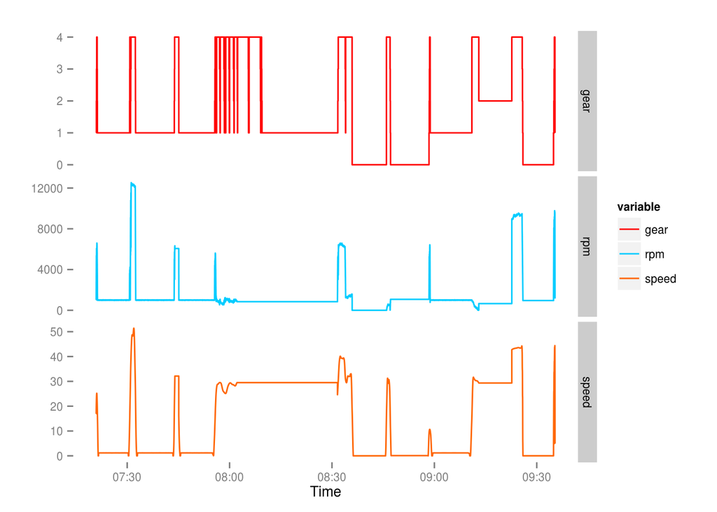

#### Perform our calculations with timeseriesr

3.Now that we have our data in memory, lets do our calculation!!! Below is the a function that will be used to calculate the gal_per_hr from our 3 variables (rpm, gear, and speed)

```r
#I basically estimated this by looking at some relations between acceleration, vehicle weight, torque, and all of the other things you see below on the magical world wide web

#calculates Fuel Usage by row, returns array of fuel usage
#engine power = torque * rpm / 5252
# The constant 5252 is the rounded value of (33,000 ft?lbf/min)/(2?? rad/rev).
#fuel usage: if Power < 0, alpha
#           : alpha + min(Pmax, engine power)
# alpha = constant idle fuel consumption rate (estimate of fuel sued to maintain engine operation)
# Pt = power = min(Pmax, torque + inertia(mass * radius^2))
gal_per_hr = function(engine_gear, engine_rpm, time, speed, alpha = .7, mass = 10000, gear_ratio = 1.2, Pmax =   200, efficiency_parameter = .02, acceleration_parameter = .01, wheel_radius){
    torque <- c(diff(engine_rpm),0)
    torque[torque<0] <- 0
    torque <- torque * engine_gear * gear_ratio
    Pt <- torque * engine_rpm / (33000/2/pi)
    Pt[Pt>200] <- 200
    engine_power <- t
    acceleration <- c(-diff(speed),0) / c(-diff(time),1)
    #Pi = Mv(kg) * acceleration * velocity /1000
    fuel <- alpha + efficiency_parameter * Pt + acceleration_parameter * acceleration * mass*.45359/1000 * speed
    fuel[fuel < alpha] <- alpha
    fuel[is.nan(fuel)] <- alpha

    return(fuel)
}
```

Actually perform that operation

```r
data2$rbinded <- lapply(data2$rbinded,function(i){
                        i$gal_per_sec <- gal_per_hr(engine_gear = i$gear, engine_rpm = i$rpm, speed = i$speed, time = i$date_time)/60/60 #currently in hours, but want it to be in seconds as the time column is in seconds
                        i %>% setDT
                        })
data2$rbinded[[1]]
```

```
##         date_time gear      rpm     speed  gal_per_sec
##     1: 1394112055    1 1012.492 16.937217 0.0008217549
##     2: 1394112055    1 1228.810 17.264578 0.0009034893
##     3: 1394112055    1 1459.631 17.585472 0.0010965335
##     4: 1394112056    1 1757.546 17.743490 0.0005422796
##     5: 1394112056    1 1705.891 18.054664 0.0014310010
##    ---
## 14081: 1394120120    1 3762.915 19.516140 0.0001944444
## 14082: 1394120120    1 2902.979 14.085581 0.0001944444
## 14083: 1394120120    1 2602.196 11.170207 0.0001944444
## 14084: 1394120121    1 1898.852  4.939276 0.0001944444
## 14085: 1394120121    1 1150.547  4.939276 0.0001944444
```

Sweeeeeet!!! So now we have done our main calculation. But we want to know the total amount of gallons each truck burned per day. We are going to use `calc_area`, which is a timeseriesr function that calculates the area under the curve. It is using a Riemann left sum approach, but others will probably be added soon enough (if your data is compressed and de-duplicated then its the right approach)

```r
#calculates area under the curve as a total
data2$gallons <- data2$rbinded %>%
                        sapply(function(x) timeseriesr::calc_area(time_date = x$date_time, value = x$gal_per_sec))
#calculates the total time range in hours (data is recorded in seconds)
data2$hours <- data2$rbinded %>%
                        sapply(function(x) (max(x$date_time) - min(x$date_time))/60/60)
#calculates the average speed
data2$mph <- data2$rbinded %>%
                        sapply(function(x) mean(x$speed))
data2[,gal_per_hr := gallons/hours]
```

```
##                  vin      day airport      rbinded   gallons    hours
## 1: 1CKPH7747ZK277944 20140306     JFK <data.table> 3.1177370 2.240531
## 2: 1CWPJ7320VE852372 20140306     JFK <data.table> 0.9673207 1.033856
## 3: 1FEMY6958XU502984 20140306     JFK <data.table> 1.5951636 1.757431
## 4: 1FVTK43691G456340 20140306     JFK <data.table> 3.6247181 3.852247
## 5: 1TULD4346YD544661 20140306     JFK <data.table> 1.6412674 1.803878
##          mph gal_per_hr
## 1:  9.026001  1.3915173
## 2: 10.746364  0.9356439
## 3: 14.793853  0.9076681
## 4: 13.923766  0.9409360
## 5:  9.326923  0.9098551
```

**Bada Bing Bada Boom aka BBBB**. We have now calculated the total amount of gallons that each truck burned, the total hours it ran, miles per hour, and its average gallons per hour. Now, lets put all of this back into HBase to move onto the day/airport.

## Store Our Results using rhbase

We are going to store all of the information that we collected back into the same HBase table for later use. That includes: 1. rbinded data.table (cause we might want to reuse it later) 2. gallons 3. total hours in operation 4. gal_per_hr 5. average mph

To do this we need to slightly reorganize our table (hopefully in the future I/someone will add a small wrapper to take care of this) to fit the `hb.put` standards. None the less, the `tidyr` package allows us to do this with ease.

```r
#First, create rowkey with unite
data3 <- tidyr::unite(data2, "rowkey",airport:vin,sep = "::")

#Second, reoganize data with gather
data3 <- tidyr::gather(data3, column, value, -rowkey,convert = T)
data3[c(1,6,11,16,21)]
```

```
##                              rowkey     column        value
## 1: JFK::20140306::1CKPH7747ZK277944    rbinded <data.table>
## 2: JFK::20140306::1CKPH7747ZK277944    gallons     3.117737
## 3: JFK::20140306::1CKPH7747ZK277944      hours     2.240531
## 4: JFK::20140306::1CKPH7747ZK277944        mph     9.026001
## 5: JFK::20140306::1CKPH7747ZK277944 gal_per_hr     1.391517
```

Great!!! Now that we have it in the format we want, lets put it back in HBase

```r
#Assuming the hb.init connection is still valid
hb.put("Test","test",rowkey = data3$rowkey, column = data3$column, value = data3$value)
```

```
## [1] TRUE
```

And just to test it out, lets see what happens when we pull back one of the new columns we added

```r
hb.pull("Test","test",c("gal_per_hr","rbinded"))
```

```
##                               rowkey column_family     column       values
##  1: JFK::20140306::1CKPH7747ZK277944          test gal_per_hr     1.391517
##  2: JFK::20140306::1CKPH7747ZK277944          test    rbinded <data.table>
##  3: JFK::20140306::1CWPJ7320VE852372          test gal_per_hr    0.9356439
##  4: JFK::20140306::1CWPJ7320VE852372          test    rbinded <data.table>
##  5: JFK::20140306::1FEMY6958XU502984          test gal_per_hr    0.9076681
##  6: JFK::20140306::1FEMY6958XU502984          test    rbinded <data.table>
##  7: JFK::20140306::1FVTK43691G456340          test gal_per_hr     0.940936
##  8: JFK::20140306::1FVTK43691G456340          test    rbinded <data.table>
##  9: JFK::20140306::1TULD4346YD544661          test gal_per_hr    0.9098551
## 10: JFK::20140306::1TULD4346YD544661          test    rbinded <data.table>
```

**BBBB!!!** Pretty cool right?

Whats great about this is that you can easily parallel this operation across multiple cores/nodes/clusters because we broke it down in intervals (airport and date). Check out the parallel package or even the rmr2 package for more details of how to do that.

If you have any suggestions, comments, or questions please feel free to contact me. Also if you would like to further contribute to the rhbase fork or timeseriesr package, I welcome all aboard.